# Dual active bridge DC-DC converter

The dual active bridge DC-DC converter shown in the figure is operated in phase shift modulation with a switching frequency of $50\,$kHz. The other parameters of the converter are $V_s = 50\,$V, $N_1:N_2 = 1:10$, $V_o = 400\,$V, $L_{LK} = 20\,\mu$H, $C_{out} = 22\,\mu$F, $R = 640\,\Omega$.

1. Determine the phase shift $\phi$.
2. Plot the current through the inductor $L_{LK}$ and mark its salient features.

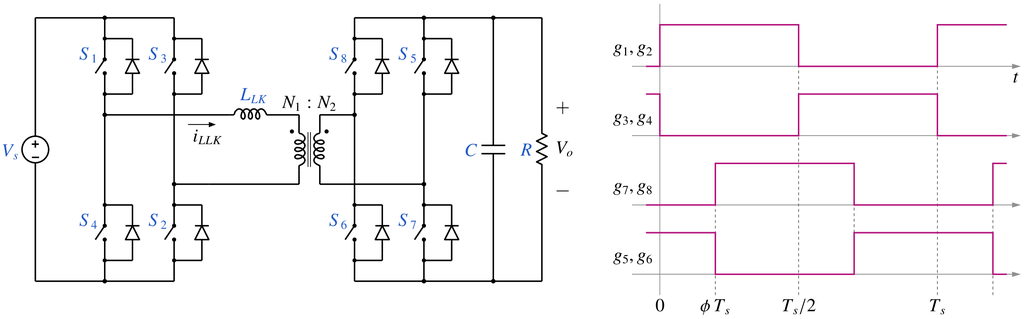

```python
from IPython.display import Image
Image(filename =r'bridge_dcdc_3_fig_1.png', width=900)
```

```python
# run this cell to view the circuit file.
%pycat bridge_dcdc_3_orig.in
```

We now replace the strings such as \$Vdc, \$L, with the values of our choice by running the python script given below. It takes an existing circuit file `bridge_dcdc_3_orig.in` and produces a new circuit file `bridge_dcdc_3.in`, after replacing \$Vdc, \$L, etc. with values of our choice.

```python
import gseim_calc as calc
s_phi = "0.16" # to be entered by user
s_Vdc = "50"
s_LLK = "20e-6"
s_R = "640"
s_C = "22e-6"
s_N1 = "1"
s_N2 = "10"

f_hz = 50.0e3
T = 1/f_hz
s_Tend = "120e-3"
Tend = float(s_Tend)
T1 = Tend - 2.0*T
s_T1 = ("%12.5E"%(T1)).strip()

phi = float(s_phi)
t0 = phi*T
s_t0 = ("%11.4E"%(t0)).strip()

l = [
  ('$Vdc', s_Vdc),
  ('$LLK', s_LLK),
  ('$R', s_R),
  ('$C', s_C),
  ('$N1', s_N1),
  ('$N2', s_N2),
  ('$Tend', s_Tend),
  ('$T1', s_T1),
  ('$t0', s_t0),
]
calc.replace_strings_1("bridge_dcdc_3_orig.in", "bridge_dcdc_3.in", l)
print('bridge_dcdc_3.in is ready for execution')
```

```
bridge_dcdc_3.in is ready for execution
```

**Execute the following cell to run GSEIM on bridge_dcdc_3.in.**

```python
import os
import dos_unix
# uncomment for windows:
#dos_unix.d2u("bridge_dcdc_3.in")
os.system('run_gseim bridge_dcdc_3.in')
```

```
Circuit: filename = bridge_dcdc_3.in
main: calling solve_trns
Transient simulation starts...
i=0
i=100000
i=200000
i=300000
GSEIM: Program completed.
```

```
0
```

The circuit file (`bridge_dcdc_3.in`) is created in the same directory as that used for launching Jupyter notebook. The last step (i.e., running `GSEIM` on `bridge_dcdc_3.in`) creates a data file called `bridge_dcdc_3.dat` in the same directory. We can now use the python code below to compute/plot the various quantities of interest.

```
filename: bridge_dcdc_3_1.dat
time points where slope of ILLK changes:
     3.1 micro-sec
     9.9 micro-sec
    13.1 micro-sec
    19.9 micro-sec
    23.1 micro-sec
    29.9 micro-sec
    33.1 micro-sec
```

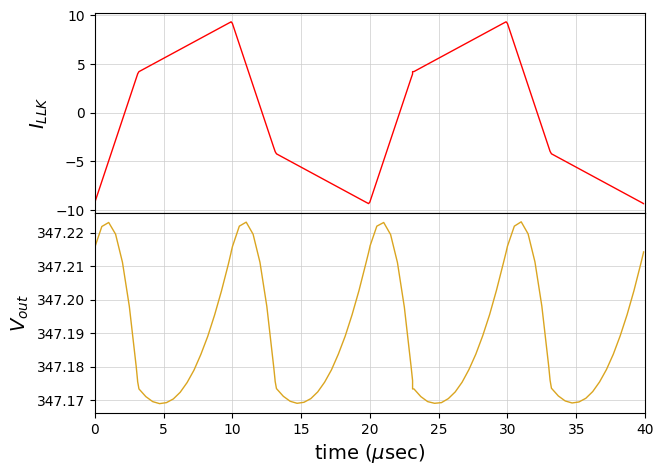

```python
import numpy as np
import matplotlib.pyplot as plt
import gseim_calc as calc
from setsize import set_size

f_hz = 50.0e3
T = 1.0/f_hz

slv = calc.slv("bridge_dcdc_3.in")

i_slv = 0
i_out = 0
filename = slv.l_filename_all[i_slv][i_out]
print('filename:', filename)
u1 = np.loadtxt(filename)
t1a = u1[:, 0]
t1 = t1a - t1a[0]

v_out = slv.get_array_double(i_slv,i_out,"v_out",u1)
ILLK  = slv.get_array_double(i_slv,i_out,"ILLK",u1)
VLLK  = slv.get_array_double(i_slv,i_out,"VLLK",u1)

VLLK = VLLK
n = np.size(VLLK)
l_index = []

for i in range(0,(n-1)):
    if (abs(VLLK[i+1]-VLLK[i])) > 1.0:
        l_index.append(i)

print('time points where slope of ILLK changes:')
for k in l_index:
    t0 = t1[k]
    print('  ', "%5.1F"%(t0*1e6), 'micro-sec')

color1='red'
color2='goldenrod'
color3='blue'
color4='green'
color5='crimson'
color6='cornflowerblue'

fig, ax = plt.subplots(2, sharex=False)
plt.subplots_adjust(wspace=0, hspace=0.0)

set_size(5.5, 4, ax[0])

for i in range(2):
    ax[i].set_xlim(left=0.0, right=2.0*T*1e6)
    ax[i].grid(color='#CCCCCC', linestyle='solid', linewidth=0.5)

ax[0].set_ylabel(r'$I_{LLK}$', fontsize=14)
ax[1].set_ylabel(r'$V_{out}$', fontsize=14)

ax[0].tick_params(labelbottom=False)

ax[0].plot(t1*1e6, ILLK , color=color1, linewidth=1.0, label="$I_{LLK}$")
ax[1].plot(t1*1e6, v_out, color=color2, linewidth=1.0, label="$V_{out}$")

ax[1].set_xlabel('time (' + r'$\mu$' + 'sec)', fontsize=14)

#plt.tight_layout()
plt.show()
```

This notebook was contributed by **Prof. Nakul Narayanan K**, Govt. Engineering College, Thrissur. He may be contacted at nakul@gectcr.ac.in.